# Data Analytics for Business

## Sessions 4-5, Clustering and Segmentation

T. Evgeniou  
INSEAD

## Clustering and Segmentation

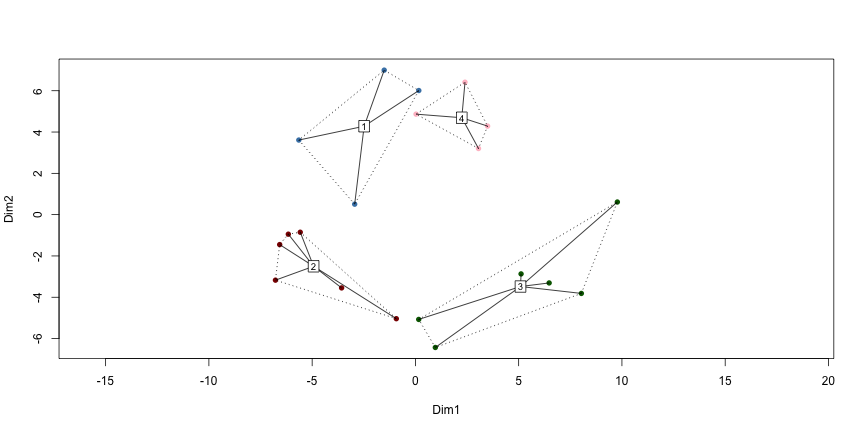

## What is Clustering and Segmentation?

Processes and tools to organize data in a few segments, with data being as similar as possible within each segment, and as different as possible across segments

## Example Usage

- Market Segmentation
- Co-Moving Asset Classes
- Geo-demographic segmentation
- Recommender Systems
- Text Mining

## A Segmentation Process

1. Confirm the data in metric
2. Decide whether to scale or standardize the data
3. Decide which variables to use for clustering
4. Define similarity or dissimilarity measures between observations
5. Visualize Individual Attributes and Pair-wise Distances between the Observations
6. Select the clustering method to use and decide how many clusters to have
7. Profile and interpret the clusters
8. Assess the robustness of our clusters

## Example Data: Market Research Survey

Size of data: 2813 observations with 82 variables each

V1: Shopping is fun (scale 1-7)

V2: Shopping is bad for your budget (scale 1-7)

V3: I combine shopping with eating out (scale 1-7)

V4: I try to get the best buys while shopping (scale 1-7)

V5: I don't care about shopping (scale 1-7)

V6: You can save lot of money by comparingprices (scale 1-7)

Income: the household income of the respondent (in dollars)

Mall.Visits: how often they visit the mall (scale 1-7)

## Step 1: Confirm the data are metric

## Step 2: Decide whether to scale or standardize the data: Summary Statistics

## Data Standardization: Example Code

```r
ProjectData_segment_scaled=apply(ProjectData_segment,2, function(r) {
  if (sd(r)!=0) {
    res=(r-mean(r))/sd(r)
    } else {
      res=0*r; res
      }
  })
```

## Standardized Data: Summary Statistics

## Step 3. Decide which variables to use for clustering

The choice of the variables used for clustering is critically important

Tpically we use different variables for segmentation (the "segmentation variables") and different ones for profiling (the "profiling variables")

Remember: Segmentation is an iterative process

## Step 4. Define similarity or dissimilarity measures between observations

Defining what we mean when we say "similar" or "different" observations is a key part of cluster analysis which often requires a lot of contextual knowledge and creativity

There are literally thousands of rigorous mathematical definitions of distance between observations/vectors

The user can manually define such distance metrics

## Distances across our data using the Euclidean distance

Pairwise Distances between the first 5 observations using The Euclidean Distance Metric

| 1 | 2 | 3 | 4 | 5 |
| --- | --- | --- | --- | --- |
| 0.0 |  |  |  |  |
| 2.2 | 0.0 |  |  |  |
| 2.4 | 1.7 | 0.0 |  |  |
| 2.4 | 1.7 | 2.4 | 0.0 |  |
| 1.7 | 1.4 | 2.2 | 2.6 | 0.0 |

## Distances across our data using the Manhattan distance

Pairwise Distances between the first 5 observations using The Manhattan Distance Metric

| 1 | 2 | 3 | 4 | 5 |
| --- | --- | --- | --- | --- |
| 0.0 |  |  |  |  |
| 5.0 | 0.0 |  |  |  |
| 4.0 | 3.0 | 0.0 |  |  |
| 4.0 | 3.0 | 4.0 | 0.0 |  |
| 3.0 | 2.0 | 5.0 | 5.0 | 0.0 |

## Manually Defined Distances: an Example

```r
My_Distance_function<-function(x,y){sum(abs(x-y)>2)}
```

## Manually Defined Distances: an Example

Pairwise Distances between the first 5 observations using a simple manually defined Distance Metric

| 1 | 2 | 3 | 4 | 5 |
| --- | --- | --- | --- | --- |
| 0.0 |  |  |  |  |
| 0.0 | 0.0 |  |  |  |
| 0.0 | 0.0 | 0.0 |  |  |
| 0.0 | 0.0 | 0.0 | 0.0 |  |
| 0.0 | 0.0 | 0.0 | 0.0 | 0.0 |

## Step 5. Visualize Individual Attributes and Pair-wise Distances between the Observations

## Histogram of all pairwise distances

Distance Used: euclidean

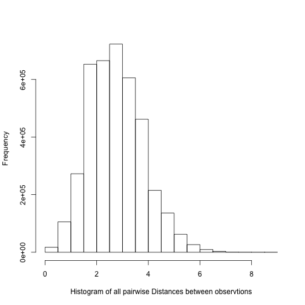

## Step 6. Select the clustering method to use and decide how many clusters to have

There are many clustering methods. Two common ones are:

- Hierarchical Methods
- Non-Hierarchical Methods (e.g. k-means)

We can plug-and-play (with CARE) this "black box" in our analysis

## Hierarchical Clustering: Dendrogram

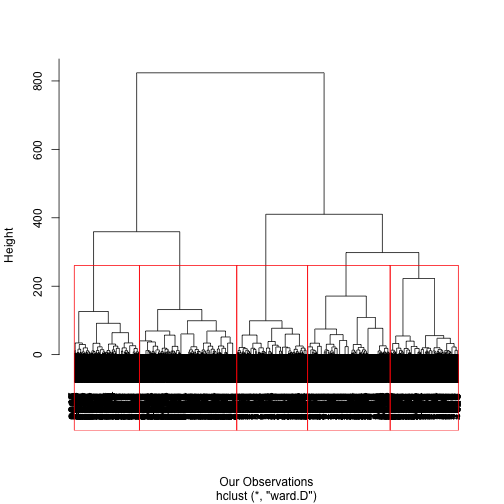

## Hierarchical Clustering Dendrogram Heights Plot

## Cluster Membership: Hierarchical Clustering

## Cluster Membership: K-means Clustering

Note: K-means does not necessarily lead to the same solution every time you run it

## Step 7. Profile and interpret the clusters

Data analytics is used to eventually make decisions, and that is feasible only when we are comfortable (enough) with our understanding of the analytics results, including our ability to clearly interpret them.

## Cluster Profiling: Cluster Centers of Profling Variables

## Interpretation: Snake Plots

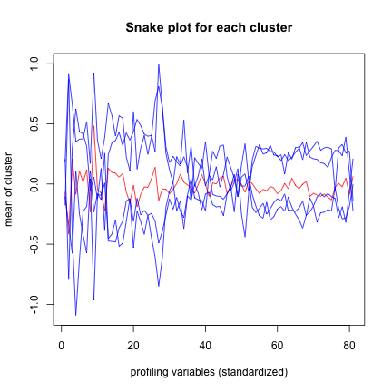

## Interpretation: Ratio to Average of Total Population (1 = Average)

|  | Segment 1 | Segment 2 | Segment 3 | Segment 4 | Segment 5 |
| --- | --- | --- | --- | --- | --- |
| Q1_1_When buying a boat I do a lot of shopping around and visit multiple dealers | 0.9864625 | 1.042183 | 1.037513 | 0.9638825 | 0.9787323 |
| Q1_2_When buying a boat getting the lowest price is more important than the boat brand | 0.8532928 | 0.7206602 | 1.320463 | 1.30526 | 0.8827231 |
| Q1_3_The brand of boat I buy says a lot about who I am | 1.067962 | 1.097725 | 1.217715 | 0.8565987 | 0.8109957 |
| Q1_4_I only consider buying a boat from a reputable brand | 0.9818343 | 1.131472 | 1.074202 | 0.7700297 | 1.023089 |
| Q1_5_I am willing to pay a premium for a brand with a reputation for high quality | 1.028278 | 1.113602 | 1.097242 | 0.8374095 | 0.9342381 |
| Q1_6_Owning a boat is a way of rewarding myself for my hard work | 1.003147 | 1.086864 | 1.078258 | 0.952131 | 0.9113504 |
| Q1_7_Owning a boat gives me a sense of achievement | 1.028793 | 1.076103 | 1.126902 | 0.9545415 | 0.8600422 |
| Q1_8_When buying a boat functionality is more important than style | 0.9495542 | 0.9878813 | 1.037298 | 1.022613 | 1.009038 |
| Q1_9_I see my boat as a status symbol | 1.180293 | 1.020704 | 1.34316 | 0.9137543 | 0.6399012 |
| Q1_10_When buying a boat I rely more on expert opinion than my own e g consumer reports salespeople | 0.9872578 | 0.9658828 | 1.100489 | 0.9775864 | 0.9765519 |
| Q1_11_I tend to perform minor boat repairs and maintenance on my own | 0.975568 | 1.042922 | 1.069869 | 0.9569368 | 0.9685387 |
| Q1_12_When it comes to boating I tend to prefer a basic boat with little to no frills | 0.9208879 | 0.8628448 | 1.136906 | 1.090919 | 1.002834 |
| Q1_13_When buying a boat I tend to buy the latest and greatest | 1.042658 | 1.079684 | 1.217342 | 0.8460342 | 0.852516 |
| Q1_14_When buying accessories for my boat I tend to buy the latest and greatest | 1.028715 | 1.101784 | 1.170681 | 0.8571395 | 0.8754167 |
| Q1_15_I am serious about the technology on my boat | 1.022107 | 1.089045 | 1.098025 | 0.8815871 | 0.9265593 |
| Q1_16_People tend to come to me for advice about boating | 1.019029 | 1.144676 | 1.191613 | 0.8767498 | 0.8251301 |
| Q1_17_I consider myself more knowledgeable about boating than the rest of my boating peers | 1.028181 | 1.101472 | 1.172947 | 0.9017842 | 0.8445279 |
| Q1_18_Boating gives me a feeling of adventure | 0.9880623 | 1.076679 | 1.040535 | 0.9744871 | 0.9438408 |
| Q1_19_Boating allows me to experience nature | 0.9728124 | 1.062821 | 1.019325 | 0.9788028 | 0.9791001 |
| Q1_20_When not on my boat I often find myself doing boating related activities | 0.9967139 | 1.134448 | 1.185061 | 0.9043107 | 0.8375858 |
| Q1_21_Boating helps me escape from everyday life and relax | 0.967335 | 1.091879 | 1.021075 | 0.9797547 | 0.9614356 |
| Q1_22_Boating helps me stay active | 0.9840897 | 1.089483 | 1.054884 | 0.9527252 | 0.942345 |
| Q1_23_Boating allows me to excel in the sports that I am passionate about e g fishing racing water sports | 0.9930931 | 1.119138 | 1.116018 | 0.9371866 | 0.8797168 |
| Q1_24_Boating gives me an outlet to socialize with family and or friends | 0.9948458 | 1.073311 | 1.045273 | 0.952095 | 0.9519897 |
| Q1_25_Being in charge of my boat is very important to me | 1.010666 | 1.097344 | 1.094783 | 0.9412192 | 0.8928667 |
| Q1_26_Having a powerful boat is what is most important to me | 1.049509 | 1.096829 | 1.246302 | 0.8900338 | 0.7840676 |
| Q1_27_Boating is the number one thing I do with my spare time | 0.954218 | 1.332674 | 1.270455 | 0.836964 | 0.7173641 |
| Q1_28_Boating is my true passion in life | 0.9880622 | 1.191324 | 1.188472 | 0.8825638 | 0.8170791 |
| Q1_29_Boating is one of many things I do in my spare time | 0.9920923 | 1.056023 | 1.046048 | 0.9529688 | 0.9653201 |
| Q2_How many powerboats do you currently own | 0.9299174 | 1.156271 | 1.10325 | 0.8909886 | 0.9475788 |

[output cut: 51 more lines]

## The data

Size of data: 2813 observations with 82 variables each

V1: Shopping is fun (scale 1-7)

V2: Shopping is bad for your budget (scale 1-7)

V3: I combine shopping with eating out (scale 1-7)

V4: I try to get the best buys while shopping (scale 1-7)

V5: I don't care about shopping (scale 1-7)

V6: You can save lot of money by comparingprices (scale 1-7)

Income: the household income of the respondent (in dollars)

Mall.Visits: how often they visit the mall (scale 1-7)

## Step 8. Assess the robustness of our clusters

Are the clusters stable when we use:

- using different subsets of the original data
- using variations of the original segmentation attributes
- using different distance metrics
- using different segmentation methods
- using different numbers of clusters

## Example Robustness Test: Different Methods

The percentage of observations belonging to the same segment is 50.4443654461429 %.

| Segment 1 | Segment 2 | Segment 3 | Segment 4 | Segment 5 |
| --- | --- | --- | --- | --- |
| 71.5 | 57.7 | 31.1 | 55.1 |  |

How much overlap should we expect across clustering solutions?

## Key Technical Terms and Lessons

- Segmentation Variables
- Profiling Variables
- Distance Metrics
- Hierarchical Clustering
- Dendrogram
- K-means Clustering
- Robustness: Statistics, Interpretation, Decisions
- Actionability, Interpretability, Statistical Robustness

## Group Work

1. How many market segments (clusters) are there? Why?
2. How would you describe the segments?
3. How would the segments inform the strategy of CreeqBoat?

## Next Class: Discriminant Analysis, Purchase Drivers, and Linking Analytics to Business Decisions